# Clasificar con K-Nearest-Neighbor

koki Orba

# ¿Qué es el algoritmo k-Nearest Neighbor ?

K-Nearest-Neighbor es un algoritmo basado en instancia de tipo supervisado de Machine Learning. Puede usarse para clasificar nuevas muestras (valores discretos) o para predecir (regresión, valores continuos).

Sirve esencialmente para clasificar valores buscando los puntos de datos «más similares» (por cercanía) aprendidos en la etapa de entrenamiento y haciendo conjeturas de nuevos puntos basado en esa clasificación.

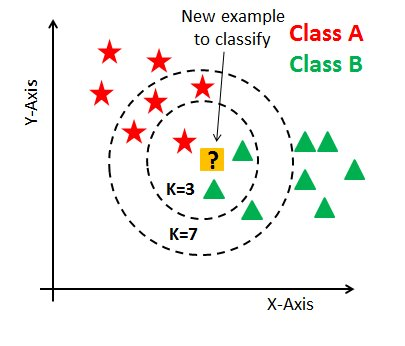

Es común encontrarse el algoritmo de K-means el cual tendemos a confundir con knn, pues en ambos tenemos un valor “K”, obstante en kmeans la «K» significa la cantidad de «grupos» (clusters) que deseamos clasificar, en K-Nearest Neighbor la «K» significa la cantidad de «puntos vecinos» que tenemos en cuenta en las cercanías para clasificar los «n» grupos -que ya se conocen de antemano, pues es un algoritmo supervisado.

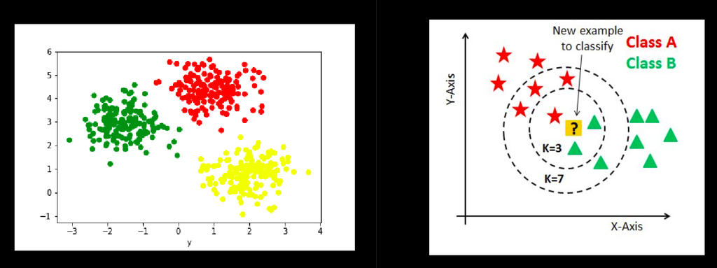

- Supervisado: esto -brevemente- quiere decir que tenemos etiquetado nuestro conjunto de datos de entrenamiento, con la clase o resultado esperado dada «una fila» de datos.
- Basado en Instancia: Esto quiere decir que nuestro algoritmo no aprende explícitamente un modelo (como por ejemplo en Regresión Logística o árboles de decisión). En cambio memoriza las instancias de entrenamiento que son usadas como «base de conocimiento» para la fase de predicción.

## ¿Cómo funciona kNN?

1. Calcular la distancia entre el item a clasificar y el resto de items del dataset de entrenamiento.

La distancia que se utiliza en este modelo es la distancia “ordinaria” entre dos puntos de un espacio euclídeo, la cual se deduce a partir del teorema de Pitágoras.
$${\displaystyle d_{E}(P_{1},P_{2})={\sqrt {(x_{2}-x_{1})^{2}+(y_{2}-y_{1})^{2}}}}$$
Por ejemplos practicos en este modelo programado no lo haremos puesto que no es necesario, ya que “R” lo hace por medio de sus funciones y la libreria class `library(class`)

2. Seleccionar los `k` elementos más cercanos (con menor distancia, según la función que se use)

Para saber nuestro número k, lo obtenemos por medio de la la raiz cuadrada del número total de atributos en una sola variable

$$k = \sqrt {\sum (1*x_{rows})}$$

# Nuestro Ejercicio

Para nuestro ejercicio, tomaremos el que este precargado en R y además es bien conocido, este es el de `iris`, y vamos utilizar las 4 primeras columnas para alimentar el algoritmo, el cual esta nos ayudara a caracterizar el los valores a predecir los valores categoricos.

Primero hacemos imports de librerías que utilizaremos para manejo de datos en el ejercício.

```r
library(class)
library(DT)
library(dplyr)
library(ROCR)
```

```r
library(ggplot2)
```

Seguidamente vamos a cargar nuestro set de datos y lo vamos a proyectar en una tabla para observar el contenido de los datos que tenemos, con la función `str`, vemos la estructura de los datos.

```r
df <- data(iris)
 str(iris)
```

```
## 'data.frame':    150 obs. of  5 variables:
##  $ Sepal.Length: num  5.1 4.9 4.7 4.6 5 5.4 4.6 5 4.4 4.9 ...
##  $ Sepal.Width : num  3.5 3 3.2 3.1 3.6 3.9 3.4 3.4 2.9 3.1 ...
##  $ Petal.Length: num  1.4 1.4 1.3 1.5 1.4 1.7 1.4 1.5 1.4 1.5 ...
##  $ Petal.Width : num  0.2 0.2 0.2 0.2 0.2 0.4 0.3 0.2 0.2 0.1 ...
##  $ Species     : Factor w/ 3 levels "setosa","versicolor",..: 1 1 1 1 1 1 1 1 1 1 ...
```

```r
 DT::datatable(iris)
```

|  | Sepal.Length | Sepal.Width | Petal.Length | Petal.Width | Species |
| --- | --- | --- | --- | --- | --- |
| 1 | 5.1 | 3.5 | 1.4 | 0.2 | setosa |
| 2 | 4.9 | 3 | 1.4 | 0.2 | setosa |
| 3 | 4.7 | 3.2 | 1.3 | 0.2 | setosa |
| 4 | 4.6 | 3.1 | 1.5 | 0.2 | setosa |
| 5 | 5 | 3.6 | 1.4 | 0.2 | setosa |
| 6 | 5.4 | 3.9 | 1.7 | 0.4 | setosa |
| 7 | 4.6 | 3.4 | 1.4 | 0.3 | setosa |
| 8 | 5 | 3.4 | 1.5 | 0.2 | setosa |
| 9 | 4.4 | 2.9 | 1.4 | 0.2 | setosa |
| 10 | 4.9 | 3.1 | 1.5 | 0.1 | setosa |

[output cut: 140 more lines]

## Modelo

```r
 ran <- sample(1:nrow(iris), 0.9 * nrow(iris))
```

```r
normalize <- function(x)
        {
        return( (x-min(x)) / (max(x) -  min(x)) )
        }
```

## Ejecución del modelo

En este paso de la ejecicion del modelo consiste en normalizar y separar los valores numericos de nuestra variable categorica, por tanto primero haremos un resumen de nuestros valores para obtener los valores minimos y maximos.

```r
summary(iris)
```

```
##   Sepal.Length    Sepal.Width     Petal.Length    Petal.Width
##  Min.   :4.300   Min.   :2.000   Min.   :1.000   Min.   :0.100
##  1st Qu.:5.100   1st Qu.:2.800   1st Qu.:1.600   1st Qu.:0.300
##  Median :5.800   Median :3.000   Median :4.350   Median :1.300
##  Mean   :5.843   Mean   :3.057   Mean   :3.758   Mean   :1.199
##  3rd Qu.:6.400   3rd Qu.:3.300   3rd Qu.:5.100   3rd Qu.:1.800
##  Max.   :7.900   Max.   :4.400   Max.   :6.900   Max.   :2.500
##        Species
##  setosa    :50
##  versicolor:50
##  virginica :50
##
##
##
```

## Preparar los datos de salida

Anterior mente en el resumen vemos que nuestros datos no se encuentran diferenciados de una forma super exagerada, no obstante es importante saber que en algunos casos esatas caracterustucas tienes valores mas grandes y produce que nuestros analicis navegue con dificultal, por lo que para obtener mayor precición es necesario normalizar nuestros valores de tipo numerico

```r
 iris_norm <- as.data.frame(lapply(iris[,1:4], normalize))
 summary(iris_norm)
```

```
##   Sepal.Length     Sepal.Width      Petal.Length     Petal.Width
##  Min.   :0.0000   Min.   :0.0000   Min.   :0.0000   Min.   :0.00000
##  1st Qu.:0.2222   1st Qu.:0.3333   1st Qu.:0.1017   1st Qu.:0.08333
##  Median :0.4167   Median :0.4167   Median :0.5678   Median :0.50000
##  Mean   :0.4287   Mean   :0.4406   Mean   :0.4675   Mean   :0.45806
##  3rd Qu.:0.5833   3rd Qu.:0.5417   3rd Qu.:0.6949   3rd Qu.:0.70833
##  Max.   :1.0000   Max.   :1.0000   Max.   :1.0000   Max.   :1.00000
```

Extraer conjunto de training, el cual va a consistir en tomar de forma aleatoria el 90% de nuestros datos y para alimentar el algoritmo.

```r
iris_train <- iris_norm[ran,]
```

Extraer conjunto de testing, el cual nos dara el 10% de observaciones.

```r
 iris_test <- iris_norm[-ran,]
```

En el caso de este dataset, vamos a extraer quinta columna del conjunto de datos del train porque se utilizará como argumento `cl` en la función `knn`, pues es nuestro valor de interes a predecir.

```r
 iris_target_category <- iris[ran,5]
```

Además se va a extrae la quinta columna con el nombre de `iris_test_category` como el conjunto de datos para medir la precisión.

```r
 iris_test_category <- iris[-ran,5]
```

En esta parte de nuestro algoritmo, veremos que para decidir la clase de un punto es muy importante el valor de k (el cual podemos obtenerlo por medio de raiz cuadrada del número total de valores de una variable(filas de un registro)), pues este terminará casi por definir a qué grupo pertenecerán los puntos, sobre todo en las «fronteras» entre grupos. PEs importante elegir valores impares de “k” para desempatar (si las features que utilizamos son pares), además tomar muchos puntos implica mejorar la precisión, no obstante entre más «puntos k», más tardará nuestro algoritmo en procesar y darnos respuesta.

Ahora vamos a correr la funcion de “knn” (`knn(train , test, cl, k = #)`) que se encuentra dentro de la libreria class, la cual nos ayudara a ejemplificar nuestro metodo.

- `train` = matriz o marco de datos de casos de conjunto de entrenamiento.
- `test` = matriz o marco de datos de casos de prueba. Un vector se interpretará como un vector de fila para un solo caso.
- `cl` = factor de clasificaciones verdaderas del conjunto de entrenamiento
- `k` = Número de vecinos

```r
sqrt(150) #Núnero recomendado de puntos k
```

```
## [1] 12.24745
```

```r
pr <- knn(iris_train,iris_test,cl=iris_target_category,k=13)
```

## Creamos la Matriz de confusión

Por medio de la matriz de confusión buscamos visualizar el desempeño del algoritmo knn que se empleo para el aprendizaje, obteniendo nuestra predicción, la cual observamos en la diagonal de esta, la cual nos indica cuantos valores se predicen por cada variable categorica

```r
 tab <- table(pr,iris_test_category)
 tab
```

```
##             iris_test_category
## pr           setosa versicolor virginica
##   setosa          8          0         0
##   versicolor      0          3         0
##   virginica       0          0         4
```

Los datos que nos encontramos por encima de nuestro diagonal, son datos mal calificados del mismo

## Nivel de exactitud

Con la función mean, vamos a tomar los mismos valores de entrada de nuestra matriz de confusión para obtener el nivel de exactitud de nuestro modelo.

$$sum(diag(x)/(sum(rowSums(x)))) * 100$$

```r
#Primera forma
accuracy <- function(x){sum(diag(x)/(sum(rowSums(x)))) * 100}
accuracy(tab)
```

```
## [1] 100
```

```r
#Segunda forma
mean(pr == iris_test_category)
```

```
## [1] 1
```